# Tidyverse CREATE

Kaylie Evans

Rashad Long

2024-04-29

## Introduction

This project showcases an example of an R Vignette, centered around the powerful visualization capabilities of the ggplot2 package. In this RMD, a dataset sourced from FiveThirtyEight is used, specifically focusing on the age distribution within the U.S. Congress (https://fivethirtyeight.com/features/aging-congress-boomers/). The goal is to demonstrate how to effectively utilize ggplot2, a part of the TidyVerse ecosystem, to create insightful and visually appealing plots from this dataset.

## Load Libraries

```r
library(tidyverse)
library(ggalt)
```

## Import CSV into R

```r
congress <- read_csv("https://raw.githubusercontent.com/fivethirtyeight/data/master/congress-demographics/data_aging_congress.csv")

glimpse(congress)
```

```
## Rows: 29,120
## Columns: 13
## $ congress      <dbl> 82, 80, 81, 82, 83, 84, 85, 86, 87, 88, 89, 90, 91, 92, …
## $ start_date    <date> 1951-01-03, 1947-01-03, 1949-01-03, 1951-01-03, 1953-01…
## $ chamber       <chr> "House", "House", "House", "House", "House", "House", "H…
## $ state_abbrev  <chr> "ND", "VA", "VA", "VA", "VA", "VA", "VA", "VA", "VA", "V…
## $ party_code    <dbl> 200, 100, 100, 100, 100, 100, 100, 100, 100, 100, 100, 1…
## $ bioname       <chr> "AANDAHL, Fred George", "ABBITT, Watkins Moorman", "ABBI…
## $ bioguide_id   <chr> "A000001", "A000002", "A000002", "A000002", "A000002", "…
## $ birthday      <date> 1897-04-09, 1908-05-21, 1908-05-21, 1908-05-21, 1908-05…
## $ cmltv_cong    <dbl> 1, 1, 2, 3, 4, 5, 6, 7, 8, 9, 10, 11, 12, 13, 1, 2, 3, 4…
## $ cmltv_chamber <dbl> 1, 1, 2, 3, 4, 5, 6, 7, 8, 9, 10, 11, 12, 13, 1, 2, 3, 4…
## $ age_days      <dbl> 19626, 14106, 14837, 15567, 16298, 17028, 17759, 18489, …
## $ age_years     <dbl> 53.73306, 38.62012, 40.62149, 42.62012, 44.62149, 46.620…
## $ generation    <chr> "Lost", "Greatest", "Greatest", "Greatest", "Greatest", …
```

## Essential and Optional Components

The grammar of graphics is the integral of ggplot2. The structure of it takes in data, a coordinate system, and specifies a geom. Depending on the geom, an x and/or y may need to be specified. These are specified in the aes function.

### Aes values: Example for Histograms

The following are required aesthetics for a histogram:

- mapping, which is the aes(x = n)
- data, the data set name to be used in the graph

The following are optional aesthetics, followed by their default values:

- stat, default value is “bin”
- position, default value is “stack”
- binwidth, default value is relative to the data set inputs
- bins, default value is 30
- na.rm, default value is FALSE
- orientation, default value is NA
- show.legend, default value is NA
- inherit.aes, default value is TRUE
- aes, the aesthetic field has the ability to contain more aesthetic specifications such as color and shapes in other geoms - default values are null for these additional mappings

### Aes Values Examples with Histograms:

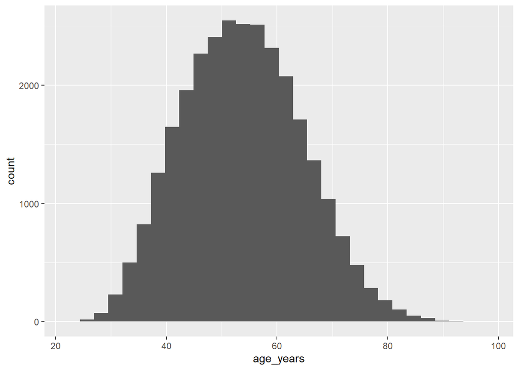

```r
#histogram of age
ggplot(congress, aes(x = age_years)) +
  geom_histogram()
```

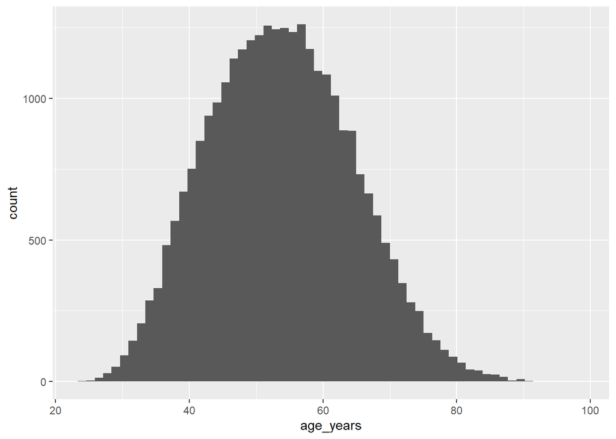

```r
#histogram of age with bin number specified
ggplot(congress, aes(x = age_years)) +
  geom_histogram(bins = 60)
```

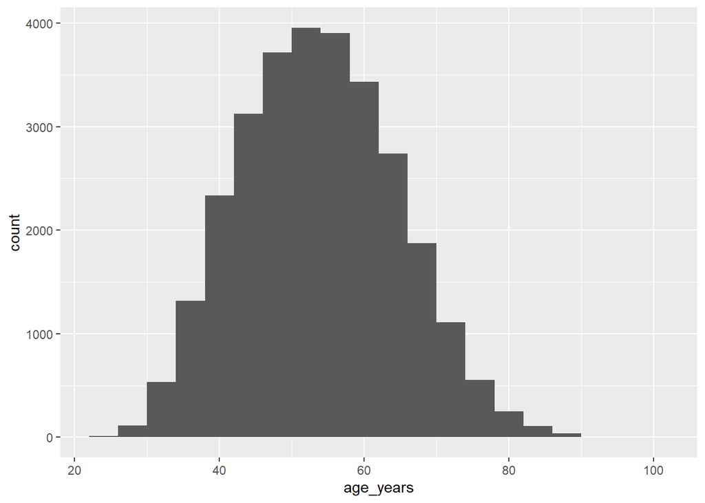

```r
#histogram of age with binwidth specified
ggplot(congress, aes(x = age_years)) +
  geom_histogram(binwidth = 4)
```

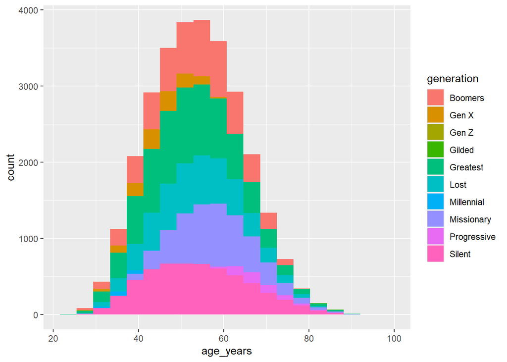

```r
#histogram of age with bins and colored by generation
ggplot(congress, aes(x = age_years)) +
  geom_histogram(aes(fill = generation), bins = 20)
```

## Examples of Graphs for Different Variable Types

The below chunks explore different combinations of variable types in ggplot2. The types explored are as follows:

1 Variable:

Continuous = geom_histogram

Discrete = geom_bar

2 Variables:

Both Continuous = geom_point

1 Continuous, 1 Discrete = geom_boxplot

### One Continuous Variable

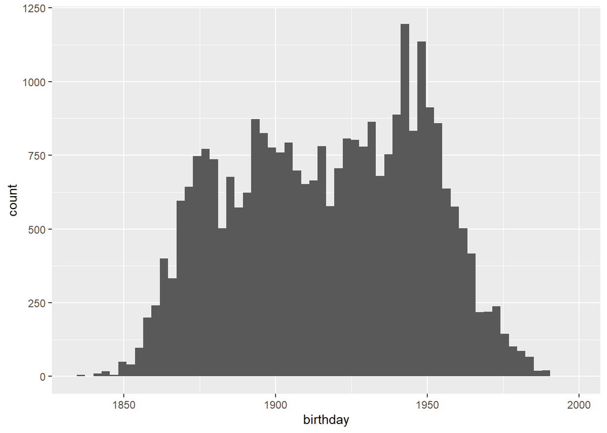

```r
#birthday at start of term histogram
ggplot(congress, aes(x = birthday)) +
  geom_histogram(bins = 60)
```

### One Continuous Variable with Color Aesthetic

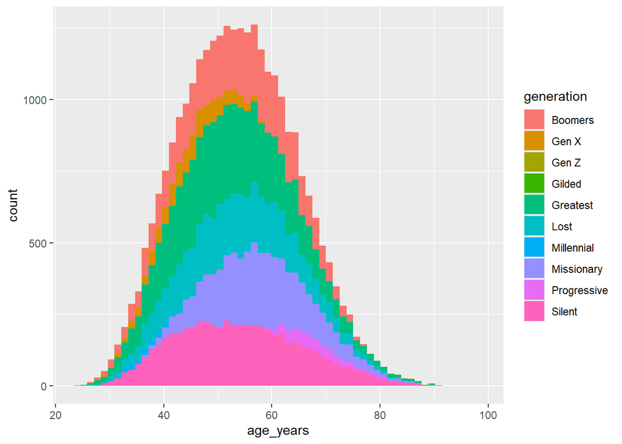

```r
#age histogram colored by generation
ggplot(congress, aes(x = age_years)) +
  geom_histogram(aes(fill = generation), bins = 60)
```

### One Discrete Variable

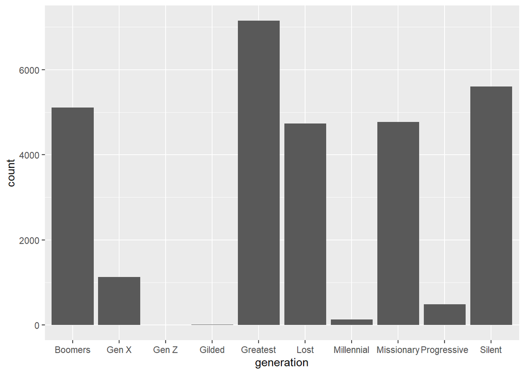

```r
#bar chart of generation frequency
ggplot(congress, aes(x = generation)) +
  geom_bar()
```

### One Discrete Variable with Color Aesthetic

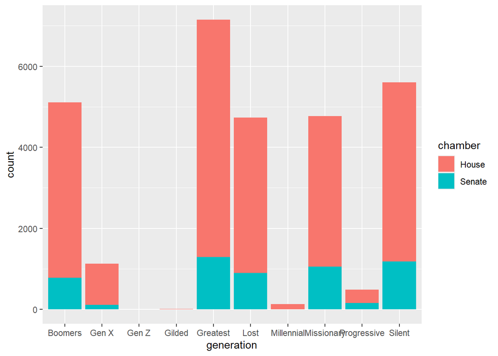

```r
#bar chart of generation frequency colored by chamber
ggplot(congress, aes(x = generation)) +
  geom_bar(aes(fill = chamber))
```

### Two Continuous Variables

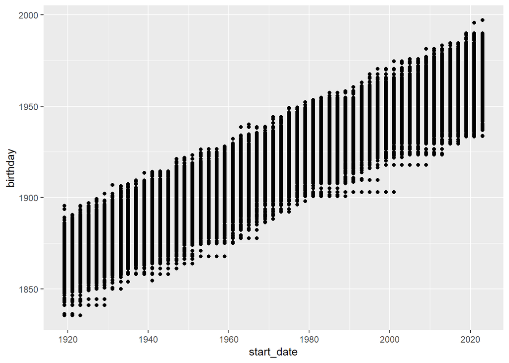

```r
#scatter plot of start date and birthday
ggplot(congress, aes(x = start_date, y = birthday)) +
  geom_point()
```

### Two Continuous Variables with Color Aesthetic

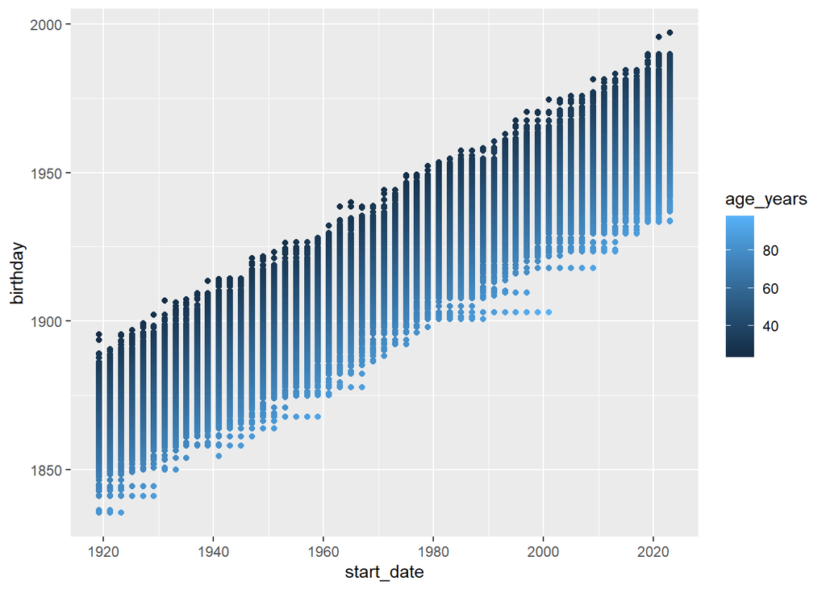

```r
#scatter plot of start date and birthday with color for age to highlight age change over time
ggplot(congress, aes(x = start_date, y = birthday)) +
  geom_point(aes(color = age_years))
```

### One Continuous Variable and One Discrete Variable

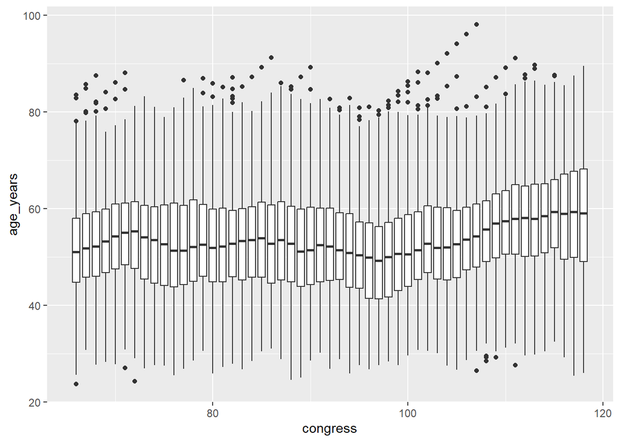

```r
#boxplots for each congress showing age IQR
ggplot(congress, aes(x = congress, y = age_years)) +
  geom_boxplot(aes(group = congress))
```

### One Continuous Variable and One Discrete Variable with Color Aesthetic

[figure not shown]

```r
#boxplots for each congress showing age IQR colored by chamber
ggplot(congress, aes(x = congress, y = age_years)) +
  geom_boxplot(aes(group = congress, fill = chamber))
```

### Correlation

`ggplot2` can also be used to visualize the correlation between variables. The `geom_point` function can be used to create a scatter plot, and the `geom_smooth` function can be used to add a line of best fit to the plot.

First we will create a variable that represents which party the member of congress belongs to. We do this by joining the congress data frame with a data frame that contains the party codes.

```r
# Read in csv file from github and join on part_code
party_codes <-
  read_csv(
    "https://raw.githubusercontent.com/pkowalchuk/SPRING2024TIDYVERSE/main/party-codes.csv"
  )

congress <- congress |>
  inner_join(party_codes, by = c("party_code" = "party_code"))
```

We can now use `ggplot2` to find correlation between age and party_name.

#### Scatterplot

The most frequently used plot for data analysis is undoubtedly the scatterplot. Whenever you want to understand the nature of relationship between two variables, invariably the first choice is the scatterplot.

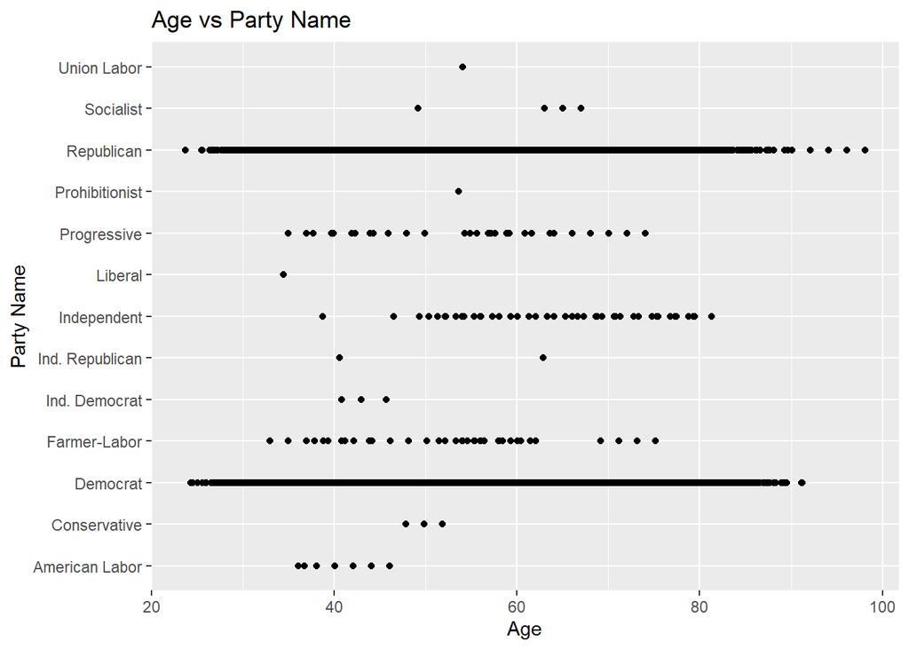

```r
ggplot(congress, aes(x = age_years, y = party_name)) +
  geom_point() +
  labs(title = "Age vs Party Name", x = "Age", y = "Party Name")
```

Sometimes to better highlight a region of the plot, we can add a encircling shape around the points.

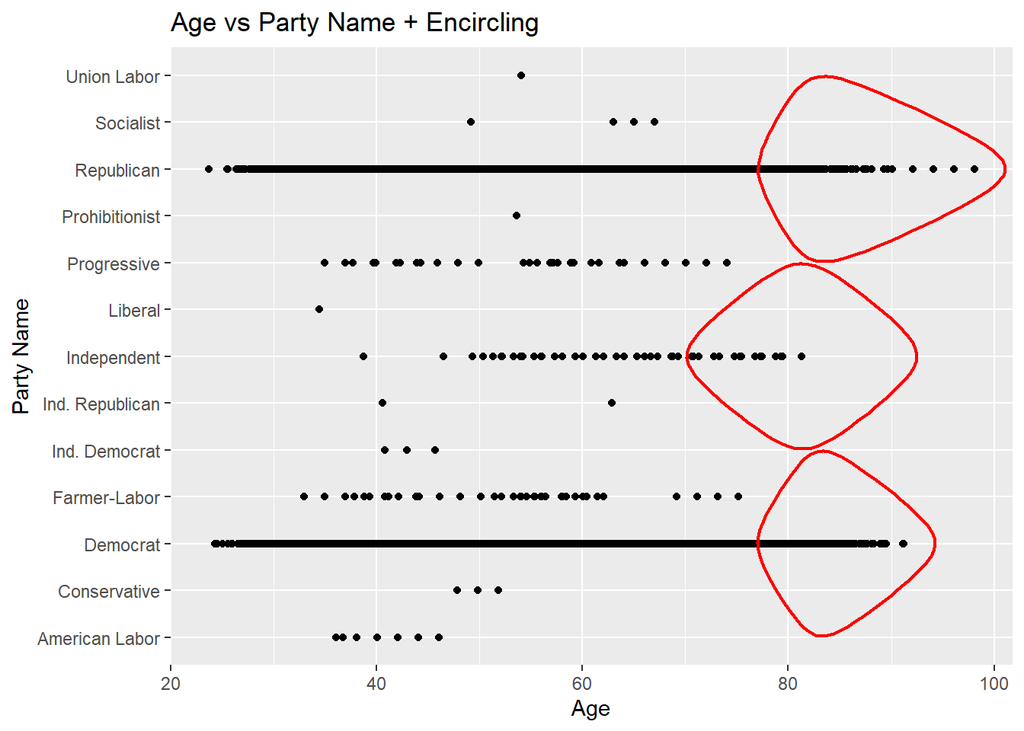

```r
ggplot(congress, aes(x = age_years, y = party_name)) +
  geom_point() +
  geom_encircle(
    aes(x = age_years, y = party_name),
    data = congress %>% filter(age_years > 80),
    color = "red",
    expand = 0.05,
    size = 2
  ) +
  labs(title = "Age vs Party Name + Encircling", x = "Age", y = "Party Name")
```